# Midterm

Michelle Nie

2/26/2019

My Github repository is located [HERE](https://github.com/michelle-nie/compscix-415-2-assignments-new)

# The tidyverse packages

## Question 1: Can you name which package is associated with each task below?

- Plotting - ggplot
- Data munging/wrangling - dplyr
- Reshaping (speading and gathering) data - tidyr
- Importing/exporting data - utils

## Question 2: Now can you name two functions that you’ve used from each package that you listed above for these tasks?

- Plotting (ggplot)
  - geom_plot
  - geom_histogram
- Data munging/wrangling (dplyr)
  - group_by
  - summarize
- Reshaping data (tidyr)
  - spread
  - gather
- Importing/exporting data (utils)
  - read.csv
  - write.csv

# R Basics

## Question 1: Fix this code with the fewest number of changes possible so it works:

```r
My_data.name___is.too00ooLong <- c( 1 , 2   , 3 )

# removed the exclamation point (!)
```

## Question 2: Fix this code so it works:

```r
my_string <- c('has', 'an', 'error', 'in', 'it')

# corrected to a lowercase c; added an end quote (')
```

## Question 3: Look at the code below and comment on what happened to the values in the vector.

```r
my_vector <- c(1, 2, '3', '4', 5)
my_vector
```

```
## [1] "1" "2" "3" "4" "5"
```

- The values in the vector were all converted into strings because ‘3’ and ‘4’ were in quotes.

# Data import/export

- Download the rail_trail.txt file from Canvas (in the Midterm Exam section) and successfully import it into R. Prove that it was imported successfully by including your import code and taking a glimpse of the result.

```r
library(tidyverse)

rail_trail <- read.csv("rail_trail.txt")

glimpse(rail_trail)
```

```
## Observations: 90
## Variables: 1
## $ hightemp.lowtemp.avgtemp.spring.summer.fall.cloudcover.precip.volume.weekday <fct> ...
```

- Export the file into a comma-separated file and name it “rail_trail.csv”. Make sure you define the path correctly so that you know where it gets saved. Then reload the file. Include your export and import code and take another glimpse.

```r
rail_trail_export <- write.csv(rail_trail, file = "rail_trail.csv")

rail_trail_csv <- read.csv("rail_trail.csv")

glimpse(rail_trail)
```

```
## Observations: 90
## Variables: 1
## $ hightemp.lowtemp.avgtemp.spring.summer.fall.cloudcover.precip.volume.weekday <fct> ...
```

# Visualization

## Question 2: Reproduce this graphic using the diamonds data set.

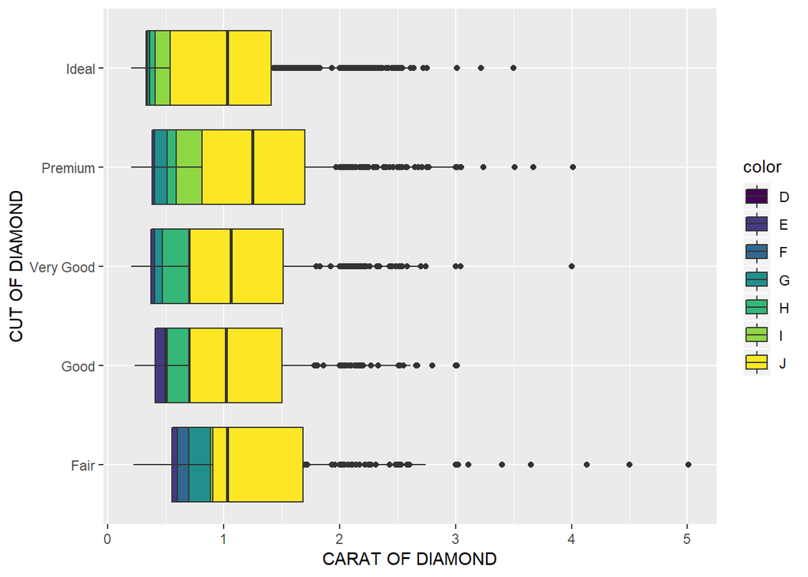

```r
library(tidyverse)

ggplot(data = diamonds) +
  geom_boxplot(mapping = aes(x = cut, y = carat, fill = color), position = "identity") +
  coord_flip() +
  xlab("CUT OF DIAMOND") +
  ylab("CARAT OF DIAMOND")
```

## Question 3: The previous graphic is not very useful. We can make it much more useful by changing one thing about it. Make the change and plot it again.

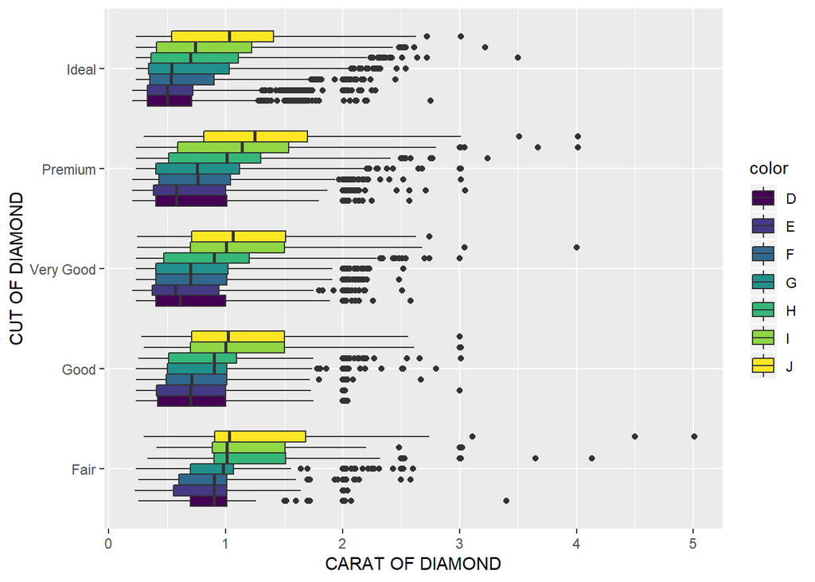

```r
ggplot(data = diamonds) +
  geom_boxplot(mapping = aes(x = cut, y = carat, fill = color), position = "dodge") +
  coord_flip() +
  xlab("CUT OF DIAMOND") +
  ylab("CARAT OF DIAMOND")
```

# Data munging and wrangling

## Question 1: Is this data “tidy”? If yes, leave it alone and go to the next problem. If no, make it tidy. Note: this data set is called table2 and is available in the tidyverse package. It should be ready for you to use after you’ve loaded the tidyverse package.

- This data is not tidy because the “type” and “count” columns include more than one variable (cases and population).

```r
table2
```

| country | year | type | count |
| --- | --- | --- | --- |
| Afghanistan | 1999 | cases | 745 |
| Afghanistan | 1999 | population | 19987071 |
| Afghanistan | 2000 | cases | 2666 |
| Afghanistan | 2000 | population | 20595360 |
| Brazil | 1999 | cases | 37737 |
| Brazil | 1999 | population | 172006362 |
| Brazil | 2000 | cases | 80488 |
| Brazil | 2000 | population | 174504898 |
| China | 1999 | cases | 212258 |
| China | 1999 | population | 1272915272 |

[output cut: 2 more lines]

```r
tidy_table2 <- table2 %>%
  spread(key = "type", value = "count")

tidy_table2
```

| country | year | cases | population |
| --- | --- | --- | --- |
| Afghanistan | 1999 | 745 | 19987071 |
| Afghanistan | 2000 | 2666 | 20595360 |
| Brazil | 1999 | 37737 | 172006362 |
| Brazil | 2000 | 80488 | 174504898 |
| China | 1999 | 212258 | 1272915272 |
| China | 2000 | 213766 | 1280428583 |

## Question 2: Create a new column in the diamonds data set called price_per_carat that shows the price of each diamond per carat (hint: divide). Only show me the code, not the output.

```r
diamonds2 <- diamonds %>%
  mutate(price_per_carat = price / carat)
```

## Question 3a: For each cut of diamond in the diamonds data set, how many diamonds, and what proportion, have a price > 10000 and a carat < 1.5? There are several ways to get to an answer, but your solution must use the data wrangling verbs from the tidyverse in order to get credit.

```r
diamonds %>%
  summarize(
    count = sum(price > 10000 & carat < 1.5, na.rm = TRUE),
    prop = mean(price > 10000 & carat < 1.5, na.rm = TRUE)
  )
```

| count | prop |
| --- | --- |
| 834 | 0.01546162 |

- 834 diamonds (1.55% of total) have a price > 10k and a carat < 1.5.

## Do the results make sense? Why?

- The results make sense because the mean price is <$4k and the median price is $2.4k. Diamonds that are greater than $10k are uncommon and could be considered outliers, hence only 1.55% of all the diamonds fit this criteria.
- On the other hand, the mean carat is .8 and the median is .7.

```r
diamonds %>%
  summarize(
    mean_price = mean(price, na.rm = TRUE),
    median_price = median(price, na.rm = TRUE)
  )
```

| mean_price | median_price |
| --- | --- |
| 3932.8 | 2401 |

```r
diamonds %>%
  summarize(
    mean_carat = mean(carat, na.rm = TRUE),
    median_carat = median(carat, na.rm = TRUE)
  )
```

| mean_carat | median_carat |
| --- | --- |
| 0.7979397 | 0.7 |

## Do we need to be wary of any of these numbers? Why?

- We need to be wary of the distribution of the prices and carats. The fact that 1.55% of diamonds fit the specified criteria may mean a lot or a little, depending on the distribution and the larger context.

# EDA

## Question 1: During what time period is this data from?

```r
glimpse(txhousing)
```

```
## Observations: 8,602
## Variables: 9
## $ city      <chr> "Abilene", "Abilene", "Abilene", "Abilene", "Abilene...
## $ year      <int> 2000, 2000, 2000, 2000, 2000, 2000, 2000, 2000, 2000...
## $ month     <int> 1, 2, 3, 4, 5, 6, 7, 8, 9, 10, 11, 12, 1, 2, 3, 4, 5...
## $ sales     <dbl> 72, 98, 130, 98, 141, 156, 152, 131, 104, 101, 100, ...
## $ volume    <dbl> 5380000, 6505000, 9285000, 9730000, 10590000, 139100...
## $ median    <dbl> 71400, 58700, 58100, 68600, 67300, 66900, 73500, 750...
## $ listings  <dbl> 701, 746, 784, 785, 794, 780, 742, 765, 771, 764, 72...
## $ inventory <dbl> 6.3, 6.6, 6.8, 6.9, 6.8, 6.6, 6.2, 6.4, 6.5, 6.6, 6....
## $ date      <dbl> 2000.000, 2000.083, 2000.167, 2000.250, 2000.333, 20...
```

```r
txhousing %>%
  group_by(year) %>%
  summarize(count = sum(listings))
```

| year | count |
| --- | --- |
| 2000 | NA |
| 2001 | NA |
| 2002 | NA |
| 2003 | NA |
| 2004 | NA |
| 2005 | NA |
| 2006 | NA |
| 2007 | NA |
| 2008 | NA |
| 2009 | NA |

[output cut: 6 more lines]

- The data is from 2000-2015.

## Question 2: How many cities are represented?

```r
txhousing %>%
  count(city)
```

| city | n |
| --- | --- |
| Abilene | 187 |
| Amarillo | 187 |
| Arlington | 187 |
| Austin | 187 |
| Bay Area | 187 |
| Beaumont | 187 |
| Brazoria County | 187 |
| Brownsville | 187 |
| Bryan-College Station | 187 |
| Collin County | 187 |

[output cut: 36 more lines]

- There are 46 cities in the dataset.

## Question 3: Which city, month and year had the highest number of sales?

```r
txhousing %>%
  group_by(city, month, year) %>%
  summarize(num_sales = sum(sales, na.rm = TRUE)) %>%
  arrange(desc(num_sales))
```

| city | month | year | num_sales |
| --- | --- | --- | --- |
| Houston | 7 | 2015 | 8945 |
| Houston | 6 | 2006 | 8628 |
| Houston | 7 | 2013 | 8468 |
| Houston | 6 | 2015 | 8449 |
| Houston | 5 | 2013 | 8439 |
| Houston | 6 | 2014 | 8391 |
| Houston | 7 | 2014 | 8391 |
| Houston | 8 | 2014 | 8167 |
| Houston | 8 | 2013 | 8155 |
| Houston | 5 | 2006 | 8040 |

[output cut: 8592 more lines]

- Houston, July 2015

## Question 4: What kind of relationship do you think exists between the number of listings and the number of sales? Check your assumption and show your work.

```r
txhousing %>%
  group_by(city, month, year) %>%
  mutate(sales_vs_listings = sales / listings)
```

| city | year | month | sales | volume | median | listings | inventory | date | sales_vs_listings |
| --- | --- | --- | --- | --- | --- | --- | --- | --- | --- |
| Abilene | 2000 | 1 | 72 | 5380000 | 71400 | 701 | 6.3 | 2000.000 | 0.102710414 |
| Abilene | 2000 | 2 | 98 | 6505000 | 58700 | 746 | 6.6 | 2000.083 | 0.131367292 |
| Abilene | 2000 | 3 | 130 | 9285000 | 58100 | 784 | 6.8 | 2000.167 | 0.165816327 |
| Abilene | 2000 | 4 | 98 | 9730000 | 68600 | 785 | 6.9 | 2000.250 | 0.124840764 |
| Abilene | 2000 | 5 | 141 | 10590000 | 67300 | 794 | 6.8 | 2000.333 | 0.177581864 |
| Abilene | 2000 | 6 | 156 | 13910000 | 66900 | 780 | 6.6 | 2000.417 | 0.200000000 |
| Abilene | 2000 | 7 | 152 | 12635000 | 73500 | 742 | 6.2 | 2000.500 | 0.204851752 |
| Abilene | 2000 | 8 | 131 | 10710000 | 75000 | 765 | 6.4 | 2000.583 | 0.171241830 |
| Abilene | 2000 | 9 | 104 | 7615000 | 64500 | 771 | 6.5 | 2000.667 | 0.134889754 |
| Abilene | 2000 | 10 | 101 | 7040000 | 59300 | 764 | 6.6 | 2000.750 | 0.132198953 |

[output cut: 8592 more lines]

## Question 5: What proportion of sales is missing for each city?

```r
txhousing %>%
  group_by(city) %>%
  summarize(missing = mean(is.na(sales))) %>%
  arrange(desc(missing))
```

| city | missing |
| --- | --- |
| South Padre Island | 0.620320856 |
| Kerrville | 0.556149733 |
| Midland | 0.401069519 |
| Odessa | 0.385026738 |
| San Marcos | 0.245989305 |
| Laredo | 0.192513369 |
| Harlingen | 0.133689840 |
| Waco | 0.101604278 |
| Texarkana | 0.090909091 |
| Brazoria County | 0.074866310 |

[output cut: 36 more lines]

## Looking at only the cities and months with greater than 500 sales:

## Question 6: Are the distributions of the median sales price (column name median), when grouped by city, different? The same? Show your work.

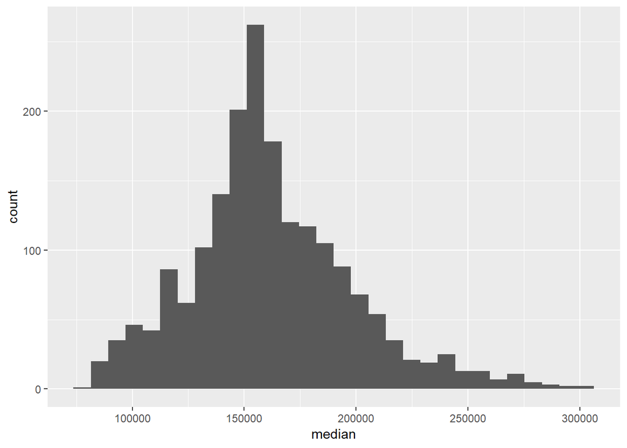

```r
city_month <- txhousing %>%
  group_by(city, month) %>%
  filter(sales > 500)

ggplot(data = city_month) +
  geom_histogram(mapping = aes(x = median))
```

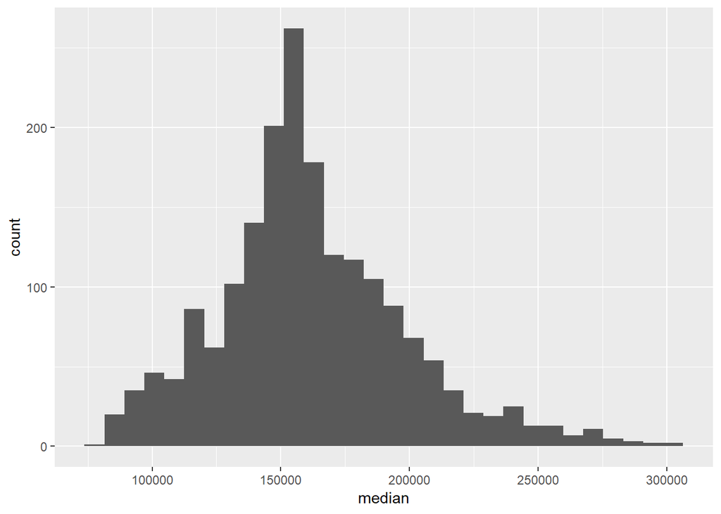

```r
city_only <- txhousing %>%
  group_by(city) %>%
  filter(sales > 500)


ggplot(data = city_only) +
  geom_histogram(mapping = aes(x = median))
```

## Question 7: Any cities that stand out that you’d want to investigate further?

```r
city_month %>%
  arrange(desc(sales))
```

| city | year | month | sales | volume | median | listings | inventory | date |
| --- | --- | --- | --- | --- | --- | --- | --- | --- |
| Houston | 2015 | 7 | 8945 | 2568156780 | 217600 | 23875 | 3.4 | 2015.500 |
| Houston | 2006 | 6 | 8628 | 1795898108 | 155200 | 36281 | 5.6 | 2006.417 |
| Houston | 2013 | 7 | 8468 | 2168720825 | 187800 | 21497 | 3.3 | 2013.500 |
| Houston | 2015 | 6 | 8449 | 2490238594 | 222400 | 22311 | 3.2 | 2015.417 |
| Houston | 2013 | 5 | 8439 | 2121508529 | 186100 | 20526 | 3.3 | 2013.333 |
| Houston | 2014 | 6 | 8391 | 2342443127 | 211200 | 19725 | 2.9 | 2014.417 |
| Houston | 2014 | 7 | 8391 | 2278932511 | 199700 | 20214 | 3.0 | 2014.500 |
| Houston | 2014 | 8 | 8167 | 2195184825 | 202400 | 20007 | 2.9 | 2014.583 |
| Houston | 2013 | 8 | 8155 | 2083377894 | 186700 | 21366 | 3.3 | 2013.583 |
| Houston | 2006 | 5 | 8040 | 1602621368 | 151200 | 35398 | 5.5 | 2006.333 |

[output cut: 1873 more lines]

```r
city_month %>%
  arrange(desc(median))
```

| city | year | month | sales | volume | median | listings | inventory | date |
| --- | --- | --- | --- | --- | --- | --- | --- | --- |
| Collin County | 2015 | 5 | 1572 | 544545110 | 304200 | 2220 | 1.6 | 2015.333 |
| Collin County | 2015 | 6 | 1789 | 614959441 | 300400 | 2314 | 1.7 | 2015.417 |
| Collin County | 2015 | 7 | 1861 | 613669702 | 292600 | 2809 | 2.1 | 2015.500 |
| Collin County | 2015 | 4 | 1391 | 456997967 | 291400 | 2018 | 1.5 | 2015.250 |
| Collin County | 2015 | 3 | 1258 | 413242198 | 285800 | 1811 | 1.4 | 2015.167 |
| Fort Bend | 2015 | 6 | 1341 | 429731131 | 284200 | 3166 | 3.0 | 2015.417 |
| Collin County | 2015 | 2 | 938 | 300904769 | 283400 | 1817 | 1.4 | 2015.083 |
| Fort Bend | 2014 | 6 | 1388 | 437581291 | 282300 | 2648 | 2.5 | 2014.417 |
| Fort Bend | 2015 | 7 | 1372 | 431875327 | 280400 | 3328 | 3.1 | 2015.500 |
| Fort Bend | 2015 | 5 | 1113 | 344045848 | 279700 | 2975 | 2.8 | 2015.333 |

[output cut: 1873 more lines]

## Question 8: Why might we want to filter out all cities and months with sales less than 500?

- Data on cities and months with sales less than 500 are likely to be outliers and potentially skew the data. They are less statistically significant for our analysis purposes.